# Hypergraph Analysis

## Import data from IMDB

```python
import pandas as pd

pricipals_df = pd.read_csv("title.pricipals.tsv", sep="\t")
pricipals_df
```

|  | tconst | ordering | nconst | category | job | characters |
| --- | --- | --- | --- | --- | --- | --- |
| 0 | tt0000001 | 1 | nm1588970 | self | \N | ["Self"] |
| 1 | tt0000001 | 2 | nm0005690 | director | \N | \N |
| 2 | tt0000001 | 3 | nm0374658 | cinematographer | director of photography | \N |
| 3 | tt0000002 | 1 | nm0721526 | director | \N | \N |
| 4 | tt0000002 | 2 | nm1335271 | composer | \N | \N |
| ... | ... | ... | ... | ... | ... | ... |
| 50014871 | tt9916880 | 4 | nm10535738 | actress | \N | ["Horrid Henry"] |
| 50014872 | tt9916880 | 5 | nm0996406 | director | principal director | \N |
| 50014873 | tt9916880 | 6 | nm1482639 | writer | \N | \N |
| 50014874 | tt9916880 | 7 | nm2586970 | writer | books | \N |
| 50014875 | tt9916880 | 8 | nm1594058 | producer | producer | \N |

50014876 rows × 6 columns

```python
basics_df = pd.read_csv("title.basics.tsv", sep="\t", low_memory=False)
basics_df
```

|  | tconst | titleType | primaryTitle | originalTitle | isAdult | startYear | endYear | runtimeMinutes | genres |
| --- | --- | --- | --- | --- | --- | --- | --- | --- | --- |
| 0 | tt0000001 | short | Carmencita | Carmencita | 0 | 1894 | \N | 1 | Documentary,Short |
| 1 | tt0000002 | short | Le clown et ses chiens | Le clown et ses chiens | 0 | 1892 | \N | 5 | Animation,Short |
| 2 | tt0000003 | short | Pauvre Pierrot | Pauvre Pierrot | 0 | 1892 | \N | 4 | Animation,Comedy,Romance |
| 3 | tt0000004 | short | Un bon bock | Un bon bock | 0 | 1892 | \N | 12 | Animation,Short |
| 4 | tt0000005 | short | Blacksmith Scene | Blacksmith Scene | 0 | 1893 | \N | 1 | Comedy,Short |
| ... | ... | ... | ... | ... | ... | ... | ... | ... | ... |
| 8870617 | tt9916848 | tvEpisode | Episode #3.17 | Episode #3.17 | 0 | 2010 | \N | \N | Action,Drama,Family |
| 8870618 | tt9916850 | tvEpisode | Episode #3.19 | Episode #3.19 | 0 | 2010 | \N | \N | Action,Drama,Family |
| 8870619 | tt9916852 | tvEpisode | Episode #3.20 | Episode #3.20 | 0 | 2010 | \N | \N | Action,Drama,Family |
| 8870620 | tt9916856 | short | The Wind | The Wind | 0 | 2015 | \N | 27 | Short |
| 8870621 | tt9916880 | tvEpisode | Horrid Henry Knows It All | Horrid Henry Knows It All | 0 | 2014 | \N | 10 | Adventure,Animation,Comedy |

8870622 rows × 9 columns

```python
name_df = pd.read_csv("name.basics.tsv", sep="\t")
name_df
```

|  | nconst | primaryName | birthYear | deathYear | primaryProfession | knownForTitles |
| --- | --- | --- | --- | --- | --- | --- |
| 0 | nm0000001 | Fred Astaire | 1899 | 1987 | soundtrack,actor,miscellaneous | tt0031983,tt0072308,tt0050419,tt0053137 |
| 1 | nm0000002 | Lauren Bacall | 1924 | 2014 | actress,soundtrack | tt0038355,tt0071877,tt0117057,tt0037382 |
| 2 | nm0000003 | Brigitte Bardot | 1934 | \N | actress,soundtrack,music_department | tt0056404,tt0054452,tt0057345,tt0049189 |
| 3 | nm0000004 | John Belushi | 1949 | 1982 | actor,soundtrack,writer | tt0077975,tt0072562,tt0080455,tt0078723 |
| 4 | nm0000005 | Ingmar Bergman | 1918 | 2007 | writer,director,actor | tt0069467,tt0083922,tt0050986,tt0060827 |
| ... | ... | ... | ... | ... | ... | ... |
| 11582529 | nm9993714 | Romeo del Rosario | \N | \N | animation_department,art_department | tt11657662,tt2455546,tt14069590 |
| 11582530 | nm9993716 | Essias Loberg | \N | \N | NaN | \N |
| 11582531 | nm9993717 | Harikrishnan Rajan | \N | \N | cinematographer | tt8736744 |
| 11582532 | nm9993718 | Aayush Nair | \N | \N | cinematographer | \N |
| 11582533 | nm9993719 | Andre Hill | \N | \N | NaN | \N |

11582534 rows × 6 columns

## Data cleaning

```python
# Only keep category column is "actor"
pricipals_df = pricipals_df[pricipals_df['category'] == 'actor']
# drop ordering, category, job and characters columns
pricipals_df = pricipals_df.drop(['ordering', 'category', 'job', 'characters'], axis=1)
pricipals_df
```

|  | tconst | nconst |
| --- | --- | --- |
| 11 | tt0000005 | nm0443482 |
| 12 | tt0000005 | nm0653042 |
| 16 | tt0000007 | nm0179163 |
| 17 | tt0000007 | nm0183947 |
| 21 | tt0000008 | nm0653028 |
| ... | ... | ... |
| 50014851 | tt9916852 | nm5519557 |
| 50014852 | tt9916852 | nm8825009 |
| 50014862 | tt9916856 | nm10538646 |
| 50014868 | tt9916880 | nm1483166 |
| 50014870 | tt9916880 | nm0286175 |

11118202 rows × 2 columns

```python
# drop titleType, originalTitle, isAdult, endYear, runtimeMinutes and genres columns
basics_df = basics_df.drop(['titleType', 'originalTitle', 'isAdult', 'endYear', 'runtimeMinutes', 'genres'], axis=1)
# Filter data by startYear is "1990"
basics_df = basics_df[basics_df['startYear'] == '1990']
basics_df
```

|  | tconst | primaryTitle | startYear |
| --- | --- | --- | --- |
| 58205 | tt0059325 | Born in '45 | 1990 |
| 58759 | tt0059900 | Wenn du groß bist, lieber Adam | 1990 |
| 63893 | tt0065188 | Vojtech, receny sirotek | 1990 |
| 67130 | tt0068494 | Domo Arigato | 1990 |
| 73695 | tt0075259 | Spy Story | 1990 |
| ... | ... | ... | ... |
| 8868538 | tt9912346 | Jeanne Bourin | 1990 |
| 8868552 | tt9912376 | Irina Ionesco | 1990 |
| 8868554 | tt9912380 | Charles Hernu | 1990 |
| 8870305 | tt9916194 | Episode dated 5 October 1990 | 1990 |
| 8870526 | tt9916654 | Episode dated 2 February 1990 | 1990 |

46819 rows × 3 columns

```python
# drop birthYear, deathYear, primaryProfession, and knownForTitles columns
name_df = name_df.drop(['birthYear', 'deathYear', 'primaryProfession', 'knownForTitles'], axis=1)
name_df
```

|  | nconst | primaryName |
| --- | --- | --- |
| 0 | nm0000001 | Fred Astaire |
| 1 | nm0000002 | Lauren Bacall |
| 2 | nm0000003 | Brigitte Bardot |
| 3 | nm0000004 | John Belushi |
| 4 | nm0000005 | Ingmar Bergman |
| ... | ... | ... |
| 11582529 | nm9993714 | Romeo del Rosario |
| 11582530 | nm9993716 | Essias Loberg |
| 11582531 | nm9993717 | Harikrishnan Rajan |
| 11582532 | nm9993718 | Aayush Nair |
| 11582533 | nm9993719 | Andre Hill |

11582534 rows × 2 columns

```python
# Merge the three tables
df = pd.merge(left=basics_df,right=pricipals_df,on='tconst')
df = pd.merge(left=df,right=name_df,on='nconst')
# Export data to "hypergraph_data.csv"
df.to_csv('hypergraph_data.csv',index = False)
```

```python
import pandas as pd

df = pd.read_csv('hypergraph_data.csv')
df
```

|  | tconst | primaryTitle | startYear | nconst | primaryName |
| --- | --- | --- | --- | --- | --- |
| 0 | tt0059325 | Born in '45 | 1990 | nm0753957 | Rolf Römer |
| 1 | tt0059325 | Born in '45 | 1990 | nm2535970 | Paul Eichbaum |
| 2 | tt0059325 | Born in '45 | 1990 | nm0537007 | Holger Mahlich |
| 3 | tt0099958 | Die Kupferfalle | 1990 | nm0537007 | Holger Mahlich |
| 4 | tt0059900 | Wenn du groß bist, lieber Adam | 1990 | nm1052658 | Stephan Jahnke |
| ... | ... | ... | ... | ... | ... |
| 78431 | tt9894646 | The Lady from Rome Part 3 | 1990 | nm7580066 | Anthony M. Chin |
| 78432 | tt9894646 | The Lady from Rome Part 3 | 1990 | nm1199293 | Giuliano Gensini |
| 78433 | tt9894646 | The Lady from Rome Part 3 | 1990 | nm0302380 | Frank Gallagher |
| 78434 | tt9894880 | Adiós a Cali | 1990 | nm2762404 | Fernell Franco |
| 78435 | tt9894880 | Adiós a Cali | 1990 | nm10529611 | Óscar Muñoz |

78436 rows × 5 columns

## The COO representation

```python
import numpy as np
import pandas as pd
import nwhy as nwhy
import copy
import os
os.environ["KMP_DUPLICATE_LIB_OK"]="TRUE"

# Select all values of the tconst column from the dataframe
tconst = copy.copy(df.iloc[:,0].values)
# Select all values of the primaryTitle column from the dataframe
primaryTitle = copy.copy(df.iloc[:,1].values)
# Select all values of the nconst column from the dataframe
nconst = copy.copy(df.iloc[:,3].values)
# Select all values of the primaryName column from the dataframe
primaryName = copy.copy(df.iloc[:,4].values)

hyperedge_to_title_dic = dict()
title_to_hyperedge_dic = dict()
title_to_tconst_dic = dict()
tconst_dic = dict()
i = 0
j = 0
for item in tconst:
    if(not tconst_dic.__contains__(item)):
        tconst_dic[item] = i
        hyperedge_to_title_dic[i] = primaryTitle[j]
        if(not title_to_hyperedge_dic.__contains__(primaryTitle[j])):
            title_to_hyperedge_dic[primaryTitle[j]] = []
            title_to_tconst_dic[primaryTitle[j]] = []
        title_to_hyperedge_dic[primaryTitle[j]].append(i)
        title_to_tconst_dic[primaryTitle[j]].append(tconst[j])
        i += 1
    tconst[j] = tconst_dic[item]
    j += 1

vertex_to_name_dic = dict()
name_to_vertex_dic = dict()
name_to_nconst_dic = dict()
nconst_dic = dict()
i = 0
j = 0
for item in nconst:
    if(not nconst_dic.__contains__(item)):
        nconst_dic[item] = i
        vertex_to_name_dic[i] = primaryName[j]
        if(not name_to_vertex_dic.__contains__(primaryName[j])):
            name_to_vertex_dic[primaryName[j]] = []
            name_to_nconst_dic[primaryName[j]] = []
        name_to_vertex_dic[primaryName[j]].append(i)
        name_to_nconst_dic[primaryName[j]].append(nconst[j])
        i += 1
    nconst[j] = nconst_dic[item]
    j += 1

weight = [1] * tconst.size

# Row of sparse matrix of the hypergraph (hyperedges)
row = tconst
# Columns of sparse matrix of the hypergraph (vertices)
col = nconst
# Weights of sparse matrix of the hypergraph
data = np.array(weight)
```

## Explore data relationships by manipulating the data table

### Query 1: How many TV shows/movies in IMDB whose startYear is 1990?

```python
def query_1_by_table():
    num_tv_movie_1990 = len(tconst_dic.keys())
    print('The number of TV shows/movies whose startYear is 1990: ', num_tv_movie_1990)
query_1_by_table()
```

```
The number of TV shows/movies whose startYear is 1990:  27612
```

### Query 2: How many actors who have acted in TV shows/movies with startYear of 1990 in IMDB?

```python
def query_2_by_table():
    num_actor_1990 = len(nconst_dic.keys())
    print('The number of actors who have acted in TV shows/movies with startYear of 1990: ', num_actor_1990)
query_2_by_table()
```

```
The number of actors who have acted in TV shows/movies with startYear of 1990:  21121
```

### Query 3: Enter a TV show/movie with startYear of 1990 in IMDB, and query the number of actors in that TV show/movie.

```python
title_tv_movie = input("Please enter a TV show/movie title: ")
def query_3_by_table(title_tv_movie):
    if(title_to_tconst_dic.__contains__(title_tv_movie)):
        # More than one line of output indicates that multiple movies have the same name.
        for tconst in title_to_tconst_dic[title_tv_movie]:
            temp_df = df[df['tconst'] == tconst]
            print('The number of actors in "', title_tv_movie, '": ', len(temp_df))
    else:
        print('Sorry, the TV show/movie "', title_tv_movie, '" was not found!')
query_3_by_table(title_tv_movie)
```

```
Please enter a TV show/movie title: Die Kupferfalle
The number of actors in " Die Kupferfalle ":  7
```

### Query 4: Enter a TV show/movie with startYear of 1990 in IMDB, and query the actors in that TV show/movie.

```python
title_tv_movie = input("Please enter a TV show/movie title: ")
def query_4_by_table(title_tv_movie):
    if(title_to_tconst_dic.__contains__(title_tv_movie)):
        # More than one block of output indicates that multiple movies have the same name.
        for tconst in title_to_tconst_dic[title_tv_movie]:
            temp_df = df[df['tconst'] == tconst]
            name_col = copy.copy(temp_df.iloc[:,4].values).tolist()
            for name in name_col:
                print('Actor', name_col.index(name) + 1, 'in "', title_tv_movie, '":', name)
    else:
        print('Sorry, the TV show/movie "', title_tv_movie, '" was not found!')
query_4_by_table(title_tv_movie)
```

```
Please enter a TV show/movie title: Die Kupferfalle
Actor 1 in " Die Kupferfalle ": Holger Mahlich
Actor 2 in " Die Kupferfalle ": Ivan Desny
Actor 3 in " Die Kupferfalle ": Wolfgang Wahl
Actor 4 in " Die Kupferfalle ": Peter Bongartz
Actor 5 in " Die Kupferfalle ": Klaus J. Behrendt
Actor 6 in " Die Kupferfalle ": Vincenzo Benestante
Actor 7 in " Die Kupferfalle ": Ulrich Gebauer
```

### Query 5: Enter an actor, and query the number of TV shows/movies with starYear of 1990 in which the actor is in.

```python
name_actor = input("Please enter an actor: ")
def query_5_by_table(name_actor):
    if(name_to_nconst_dic.__contains__(name_actor)):
        # More than one line of output indicates that multiple actors have the same name.
        for nconst in name_to_nconst_dic[name_actor]:
            temp_df = df[df['nconst'] == nconst]
            print('The number of TV shows/movies with startYear of 1990 "', name_actor, '" is in: ', len(temp_df))
    else:
        print('Sorry, the actor "', name_actor, '" was not found!')
query_5_by_table(name_actor)
```

```
Please enter an actor: Holger Mahlich
The number of TV shows/movies with startYear of 1990 " Holger Mahlich " is in:  2
```

### Query 6: Enter an actor, and query TV shows/movies with starYear of 1990 in which the actor is in.

```python
name_actor = input("Please enter an actor: ")
def query_6_by_table(name_actor):
    if(name_to_nconst_dic.__contains__(name_actor)):
        # More than one block of output indicates that multiple actors have the same name.
        for nconst in name_to_nconst_dic[name_actor]:
            temp_df = df[df['nconst'] == nconst]
            title_col = copy.copy(temp_df.iloc[:,1].values).tolist()
            for title in title_col:
                print('TV show/movie', title_col.index(title) + 1, '"', name_actor, '" is in: ', title)
    else:
        print('Sorry, the actor "', name_actor, '" was not found!')
query_6_by_table(name_actor)
```

```
Please enter an actor: Holger Mahlich
TV show/movie 1 " Holger Mahlich " is in:  Born in '45
TV show/movie 2 " Holger Mahlich " is in:  Die Kupferfalle
```

## Create Hypergraph

```python
# Create the hypergraph
h = nwhy.NWHypergraph(row, col, data)
print('Hypergraph created successfully!', h)
```

```
Hypergraph created successfully! <nwhy.NWHypergraph object at 0x7f1332a2aef0>
```

## Visualize a part of the hypergraph through Hypernetx-Widget

```
Please enter the number of hyperedges that you want to form a part of the hypergraph: 7
```

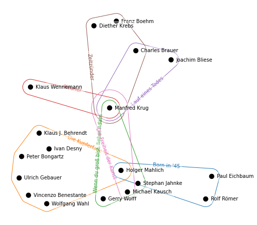

```python
import imp
import hypernetx as hnx

N_hyperedges = int(input("Please enter the number of hyperedges that you want to form a part of the hypergraph: "))
hyperedges = np.arange(N_hyperedges)
scenes = dict()
for hyperedge in hyperedges:
    title = hyperedge_to_title_dic[hyperedge]
    scenes[title] = []
    vertices = h.edge_incidence(hyperedge)
    for vertex in vertices:
        name = vertex_to_name_dic[vertex]
        scenes[title].append(name)
    scenes[title] = tuple(scenes[title])

H = hnx.Hypergraph(scenes)
hnx.draw(H)
```

## NWHypergraph class methods:

```python
# NWHypergraph class methods:

# print('-- collapsing edges without returning equal class')
# equal_class = h.collapse_edges()
# print(equal_class)

# print('-- collapsing nodes without returning equal class')
# equal_class = h.collapse_nodes()
# print(equal_class)

# print('-- collapsing nodes and edges without returning equal class')
# equal_class = h.collapse_nodes_and_edges()
# print(equal_class)

# print('-- collapsing edges with returning equal class')
# equal_class = h.collapse_edges(return_equivalence_class=True)
# print(equal_class)

# print('-- collapsing nodes with returning equal class')
# equal_class = h.collapse_nodes(return_equivalence_class=True)
# print(equal_class)

# print('-- collapsing nodes and edges with returning equal class')
# equal_class = h.collapse_nodes_and_edges(return_equivalence_class=True)
# print(equal_class)

# print('-- edge_size_dist()')
# equal_class = h.edge_size_dist()
# print(equal_class)

# print('-- node_size_dist()')
# equal_class = h.node_size_dist()
# print(equal_class)

# print('-- edge_incidence(edge)')
# equal_class = h.edge_incidence(666)
# print(equal_class)

# print('-- node_incidence(node)')
# equal_class = h.node_incidence(666)
# print(equal_class)

# print('-- degree(node, min_size=1, max_size=None)')
# equal_class = h.degree(666, min_size=1, max_size=None)
# print(equal_class)

# print('-- size(edge, min_degree=1, max_degree=None)')
# equal_class = h.size(666, min_degree=1, max_degree=None)
# print(equal_class)

# print('-- dim(edge)')
# equal_class = h.dim(666)
# print(equal_class)

# print('-- number_of_nodes()')
# equal_class = h.number_of_nodes()
# print(equal_class)

# print('-- number_of_edges()')
# equal_class = h.number_of_edges()
# print(equal_class)

# print('-- singletons()')
# equal_class = h.singletons()
# print(equal_class)

# print('-- toplexes()')
# equal_class = h.toplexes()
# print(equal_class)

# print('-- s_linegraph(s=1, edges=True)')
# equal_class = h.s_linegraph(s=1, edges=True)
# print(equal_class)

# print('-- s_linegraphs(l, edges=True)')
# equal_class = h.s_linegraphs([1,2,3,4,5,6], edges=True)
# print(equal_class)
```

## Hypergraph application(analysis)

### Query 1: How many TV shows/movies in IMDB whose startYear is 1990?

```python
def query_1_by_hypergraph():
    num_tv_movie_1990 = h.number_of_edges()
    print('The number of TV shows/movies whose startYear is 1990: ', num_tv_movie_1990)
query_1_by_hypergraph()
```

```
The number of TV shows/movies whose startYear is 1990:  27612
```

### Query 2: How many actors who have acted in TV shows/movies with startYear of 1990 in IMDB?

```python
def query_2_by_hypergraph():
    num_actor_1990 = h.number_of_nodes()
    print('The number of actors who have acted in TV shows/movies with startYear of 1990: ', num_actor_1990)
query_2_by_hypergraph()
```

```
The number of actors who have acted in TV shows/movies with startYear of 1990:  21121
```

### Query 3: Enter a TV show/movie with startYear of 1990 in IMDB, and query the number of actors in that TV show/movie.

```python
title_tv_movie = input("Please enter a TV show/movie title: ")
def query_3_by_hypergraph(title_tv_movie):
    if(title_to_hyperedge_dic.__contains__(title_tv_movie)):
        # More than one line of output indicates that multiple movies have the same name.
        for hyperedge in title_to_hyperedge_dic[title_tv_movie]:
            num_actor_tv_movie = h.size(hyperedge, min_degree=1, max_degree=None)
            print('The number of actors in "', title_tv_movie, '": ', num_actor_tv_movie)
    else:
        print('Sorry, the TV show/movie "', title_tv_movie, '" was not found!')
query_3_by_hypergraph(title_tv_movie)
```

```
Please enter a TV show/movie title: Die Kupferfalle
The number of actors in " Die Kupferfalle ":  7
```

### Query 4: Enter a TV show/movie with startYear of 1990 in IMDB, and query the actors in that TV show/movie.

```python
title_tv_movie = input("Please enter a TV show/movie title: ")
def query_4_by_hypergraph(title_tv_movie):
    if(title_to_hyperedge_dic.__contains__(title_tv_movie)):
        # More than one block of output indicates that multiple movies have the same name.
        for hyperedge in title_to_hyperedge_dic[title_tv_movie]:
            vertices = h.edge_incidence(hyperedge)
            for vertex in vertices:
                name = vertex_to_name_dic[vertex]
                print('Actor', vertices.index(vertex) + 1, 'in "', title_tv_movie, '":', name)
    else:
        print('Sorry, the TV show/movie "', title_tv_movie, '" was not found!')
query_4_by_hypergraph(title_tv_movie)
```

```
Please enter a TV show/movie title: Die Kupferfalle
Actor 1 in " Die Kupferfalle ": Holger Mahlich
Actor 2 in " Die Kupferfalle ": Ivan Desny
Actor 3 in " Die Kupferfalle ": Wolfgang Wahl
Actor 4 in " Die Kupferfalle ": Peter Bongartz
Actor 5 in " Die Kupferfalle ": Klaus J. Behrendt
Actor 6 in " Die Kupferfalle ": Vincenzo Benestante
Actor 7 in " Die Kupferfalle ": Ulrich Gebauer
```

### Query 5: Enter an actor, and query the number of TV shows/movies with starYear of 1990 in which the actor is in.

```python
name_actor = input("Please enter an actor: ")
def query_5_by_hypergraph(name_actor):
    if(name_to_vertex_dic.__contains__(name_actor)):
        # More than one line of output indicates that multiple actors have the same name.
        for vertex in name_to_vertex_dic[name_actor]:
            num_tv_movie_actor = h.degree(vertex, min_size=1, max_size=None)
            print('The number of TV shows/movies with startYear of 1990 "', name_actor, '" is in: ', num_tv_movie_actor)
    else:
        print('Sorry, the actor "', name_actor, '" was not found!')
query_5_by_hypergraph(name_actor)
```

```
Please enter an actor: Holger Mahlich
The number of TV shows/movies with startYear of 1990 " Holger Mahlich " is in:  2
```

### Query 6: Enter an actor, and query TV shows/movies with starYear of 1990 in which the actor is in.

```python
name_actor = input("Please enter an actor: ")
def query_6_by_hypergraph(name_actor):
    if(name_to_vertex_dic.__contains__(name_actor)):
        # More than one block of output indicates that multiple actors have the same name.
        for vertex in name_to_vertex_dic[name_actor]:
            hyperedges = h.node_incidence(vertex)
            for hyperedge in hyperedges:
                title = hyperedge_to_title_dic[hyperedge]
                print('TV show/movie', hyperedges.index(hyperedge) + 1, '"', name_actor, '" is in: ', title)
    else:
        print('Sorry, the actor "', name_actor, '" was not found!')
query_6_by_hypergraph(name_actor)
```

```
Please enter an actor: Holger Mahlich
TV show/movie 1 " Holger Mahlich " is in:  Born in '45
TV show/movie 2 " Holger Mahlich " is in:  Die Kupferfalle
```

### Query 7: Find the top N TV shows/movies with the most actors

```python
N = int(input("Please enter the value of N: "))
num_vertices_arr = h.edge_size_dist()
desc_num_vertices_arr = sorted(num_vertices_arr, reverse = True)
N_desc_num_vertices_arr = desc_num_vertices_arr[:N]
print('Top #\tTV show/movie title\tthe number of actors\tactors\n')
i = 1
title_arr = []
num_actor_arr = []
for item in N_desc_num_vertices_arr:
    idx = num_vertices_arr.index(item)
    num_vertices_arr[idx] = -1
    title = hyperedge_to_title_dic[idx]
    title_arr.append(title)
    num_actor_arr.append(item)
    print('Top', i, '\t', title, '\t\t', item, end='\t')
    vertices = h.edge_incidence(idx)
    for vertex in vertices:
        name = vertex_to_name_dic[vertex]
        print(name,end = ', ')
    print('\n')
    i += 1
```

```
Please enter the value of N: 10
Top #	TV show/movie title	the number of actors	actors

Top 1 	 Top Cops 		 10	Steve Adams, Jeffrey Knight, Chris Potter, Victor Ertmanis, Matt Cooke, Bill Lake, Joseph Griffin, William Colgate, Allan Clow, Timm Zemanek,

Top 2 	 S*M*A*S*H 		 10	Tor Isedal, Måns Herngren, Svante Grundberg, Peter Wahlbeck, Felix Herngren, Sten Ljunggren, Tomas Norström, Claes Månsson, Per Eggers, Björn Granath,

Top 3 	 Barnyard Commandos 		 10	Pat Fraley, Thom Bray, S. Scott Bullock, Marc François, Paul Kreppel, John Mariano, Robert Ridgely, Lennie Weinrib, Danny Wells, Jacques Ferrière,

Top 4 	 Voyna na zapadnom napravlenii 		 10	Oleg Savkin, Nikolay Oleynik, Viktor Stepanov, Archil Gomiashvili, Mikhail Ulyanov, Igor Taradaikin, Pavel Morozenko, Pavel Makhotin, Vitali Rosstalnoy, Nikolay Zasukhin,

Top 5 	 O Rato dos Livros 		 10	José Eduardo, Rui Anjos, Orlando Costa, Fernando Gomes, António Feio, Quim Cachopo, Carlos Alberto Moniz, Waldemar de Souza, João Azevedo, Almeno Gonçalves,

Top 6 	 Don Tonino e la casa dei veleni 		 10	Giampiero Bianchi, Andrea Roncato, Gigi Sammarchi, Cesare Gallarini, Marco Bechini, Tommy Bianco, Sante Calogero, Salvatore Ciraolo, Marco Della Noce, Danilo Fernandez,

Top 7 	 De opendeurdag 		 10	Jacques Vermeire, Chris Cauwenberghs, Frank Dingenen, Guido Lauwaert, Vic Moeremans, Günther Lesage, Hans Cardijn, Bart De Pauw, Wouter Denayer, Wim Geysen,

Top 8 	 Het medisch onderzoek 		 10	Jacques Vermeire, Frank Dingenen, Guido Lauwaert, Günther Lesage, Hans Cardijn, Bart De Pauw, Wouter Denayer, Wim Geysen, Rob Renckens, Gert Nevens,

Top 9 	 De inspecteur 		 10	Jacques Vermeire, Koen Crucke, Chris Cauwenberghs, Frank Dingenen, Rudi Delhem, Hans Cardijn, Bart De Pauw, Wouter Denayer, Stany Crets, Koen De Cauter,

Top 10 	 Buys op de buis 		 10	Jacques Vermeire, Koen Crucke, Chris Cauwenberghs, Frank Dingenen, Günther Lesage, Hans Cardijn, Bart De Pauw, Wouter Denayer, Wim Geysen, Emiel Goelen,
```

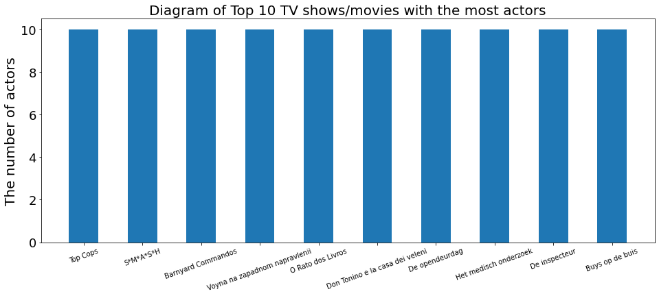

```python
import matplotlib.pyplot as plt
x = title_arr
y = num_actor_arr
plt.figure(figsize=(16, 6))
plt.bar(x, y, width=0.5)
plt.xticks(fontsize=10, rotation=20)
plt.yticks(fontsize=18)
plt.ylabel(u'The number of actors', fontsize=20)
diagram_title = str(N).join(['Diagram of Top ',' TV shows/movies with the most actors'])
plt.title(diagram_title, fontsize=20)
plt.show()
```

### Query 8: Find the top N actors with the most appearance times

```python
N = int(input("Please enter the value of N: "))
num_hyperedges_arr = h.node_size_dist()
desc_num_hyperedges_arr = sorted(num_hyperedges_arr, reverse = True)
N_desc_num_hyperedges_arr = desc_num_hyperedges_arr[:N]
print('Top #\tname\tthe number of TV shows/movies\tTV shows/movies\n')
i = 1
name_arr = []
num_tv_movie_arr = []
for item in N_desc_num_hyperedges_arr:
    idx = num_hyperedges_arr.index(item)
    num_hyperedges_arr[idx] = -1
    name = vertex_to_name_dic[idx]
    name_arr.append(name)
    num_tv_movie_arr.append(item)
    print('Top', i, '\t', name, '\t\t', item, end='\t')
    hyperedges = h.node_incidence(idx)
    for hyperedge in hyperedges:
        if(hyperedges.index(hyperedge) == 10):
            print('......')
            break
        title = hyperedge_to_title_dic[hyperedge]
        print(title,end = ', ')
    print('\n')
    i += 1
```

```
Please enter the value of N: 10
Top #	name	the number of TV shows/movies	TV shows/movies

Top 1 	 Eduardo Yáñez 		 344	Yo compro esa mujer, Episode #1.4, Episode #1.6, Episode #1.7, Episode #1.8, Episode #1.9, Episode #1.10, Episode #1.5, Episode #1.14, Episode #1.17, ......


Top 2 	 Omar Fierro 		 259	Lo inesperado, Cuando llega el amor, Furia asesina, Mi pequeña Soledad, Episode #1.4, Episode #1.5, Episode #1.6, Episode #1.7, Episode #1.8, Episode #1.9, ......


Top 3 	 Fernando Carrillo 		 251	Pasionaria, Episode #1.4, Episode #1.5, Episode #1.6, Episode #1.7, Episode #1.8, Episode #1.9, Episode #1.10, Episode #1.11, Episode #1.12, ......


Top 4 	 Henry Galué 		 251	Pasionaria, Episode #1.4, Episode #1.5, Episode #1.6, Episode #1.7, Episode #1.8, Episode #1.9, Episode #1.10, Episode #1.11, Episode #1.12, ......


Top 5 	 Luis Eduardo Arango 		 223	Música, maestro, Episode #2.60, Episode #1.4, Episode #1.6, Episode #1.5, Episode #1.7, Episode #1.9, Episode #1.8, Episode #1.11, Episode #1.10, ......


Top 6 	 Fernando González Pacheco 		 220	Música, maestro, Episode #2.60, Episode #1.4, Episode #1.6, Episode #1.5, Episode #1.7, Episode #1.9, Episode #1.8, Episode #1.11, Episode #1.10, ......


Top 7 	 Raúl Amundaray 		 211	Emperatriz, Episode #1.2, Episode #1.3, Episode #1.4, Episode #1.6, Episode #1.5, Episode #1.7, Episode #1.8, Episode #1.9, Episode #1.10, ......


Top 8 	 Eduardo Serrano 		 211	Emperatriz, Episode #1.2, Episode #1.3, Episode #1.4, Episode #1.6, Episode #1.5, Episode #1.7, Episode #1.8, Episode #1.9, Episode #1.10, ......


Top 9 	 Guillermo Dávila 		 209	Adorable Monica, Episode #1.4, Episode #1.5, Episode #1.6, Episode #1.7, Episode #1.8, Episode #1.9, Episode #1.10, Episode #1.11, Episode #1.13, ......


Top 10 	 Marcos Palmeira 		 207	Carnaval, Desire, Pantanal, Stelinha, Barrela: Escola de Crimes, Making of 'Pantanal', Episode #1.7, Episode #1.8, Episode #1.9, Episode #1.10, ......
```

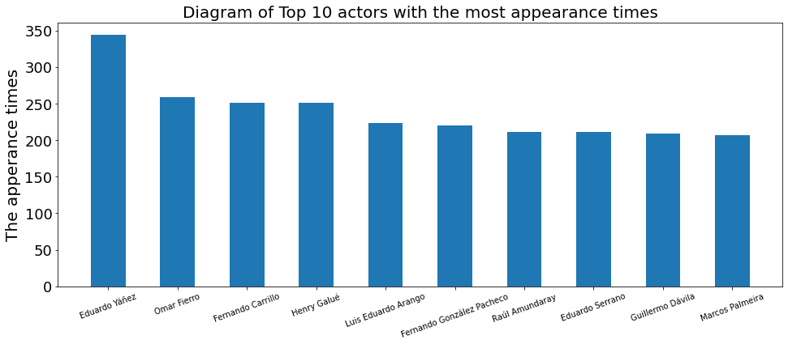

```python
x = name_arr
y = num_tv_movie_arr
plt.figure(figsize=(16, 6))
plt.bar(x, y, width=0.5)
plt.xticks(fontsize=10, rotation=20)
plt.yticks(fontsize=18)
plt.ylabel(u'The apperance times', fontsize=20)
diagram_title = str(N).join(['Diagram of Top ',' actors with the most appearance times'])
plt.title(diagram_title, fontsize=20)
plt.show()
```

### Query 9: Find movies with only one actor in it, and that actor only acted in that movie.

```python
singleton_hyperedges = h.singletons()
if(len(singleton_hyperedges) > 0):
    print('title\t\t\t\t\t\t\tactor\n')
else:
    print('There is no such movie.')
for hyperedge in singleton_hyperedges:
    if(singleton_hyperedges.index(hyperedge) == 30):
        print('......')
        break
    title = hyperedge_to_title_dic[hyperedge]
    print(title, end = '\t\t\t\t\t\t\t')
    vertices = h.edge_incidence(hyperedge)
    name = vertex_to_name_dic[vertices[0]]
    print(name)
```

```
title							actor

Dragon Hunt							B. Bob
Man Eaters							Daniel Colas
Sometime in August							Craig Lorimer
The American Angels: Baptism of Blood							Tray Loren
Cézanne - Conversation with Joachim Gasquet							Jean-Marie Straub
Les noces de papier							Manuel Aranguiz
Ono							Rolan Bykov
Party Girls							Kurt Woodruff
A Woman's Revenge							Jean-Louis Murat
Forbidden Love							Hans-Peter Dahm
America Tonight							Fred Melamed
The Crystal Maze							Adam Buxton
Kevin Seal, Sporting Fool							Kevin Seal
Marleneken							Wolfried Lier
On Scene: Emergency Response							Dave Forman
Overtime... with Pat O'Brien							Pat O'Brien
Alan Alda in Scientific American Frontiers							John Osborne
Video Challenge							Steve Kelley
All the Vermeers in New York							Stephen Lack
American Dream							Juan Munoz
Artikos							Nelson Villagra
Aschenglut							Mathieu Carrière
Baito							Jan Dop
Basket Case 2							Kevin Van Hentenryck
Die Beichte							Jochen Kuhn
Best Shots							Mick Best
Der Blasi							Reinhard Nowak
Blue Bayou							Michael Audley
Blue Planet							James Buchli
Le blé en herbe							Matthieu Rozé
......
```

## Comparisons of results and runtime between NWhy lib and the approach to manipulate the data table

### Comparison 1 (Query 1)

```python
from time import time

print('Query 1:')
print('\n--- Query 1 through manipulating the data table ---')
t_start=time()
query_1_by_table()
t_end=time()
t_cost=t_end-t_start
print('Manipulating the data table takes %0.8f seconds'%t_cost)

print('\n--- Query 1 through NWhy lib ---')
t_start=time()
query_1_by_hypergraph()
t_end=time()
t_cost=t_end-t_start
print('NWhy lib takes %0.8f seconds'%t_cost)

del t_end,t_start,t_cost
```

```
Query 1:

--- Query 1 through manipulating the data table ---
The number of TV shows/movies whose startYear is 1990:  27612
Manipulating the data table takes 0.00009036 seconds

--- Query 1 through NWhy lib ---
The number of TV shows/movies whose startYear is 1990:  27612
NWhy lib takes 0.00006247 seconds
```

### Comparison 2 (Query 2)

```python
print('Query 2:')
print('\n--- Query 2 through manipulating the data table ---')
t_start=time()
query_2_by_table()
t_end=time()
t_cost=t_end-t_start
print('Manipulating the data table takes %0.8f seconds'%t_cost)

print('\n--- Query 2 through NWhy lib ---')
t_start=time()
query_2_by_hypergraph()
t_end=time()
t_cost=t_end-t_start
print('NWhy lib takes %0.8f seconds'%t_cost)

del t_end,t_start,t_cost
```

```
Query 2:

--- Query 2 through manipulating the data table ---
The number of actors who have acted in TV shows/movies with startYear of 1990:  21121
Manipulating the data table takes 0.00005674 seconds

--- Query 2 through NWhy lib ---
The number of actors who have acted in TV shows/movies with startYear of 1990:  21121
NWhy lib takes 0.00005627 seconds
```

### Comparison 3 (Query 3)

```python
print('Query 3:\n')
title_tv_movie = input("Please enter a TV show/movie title: ")
print('\n--- Query 3 through manipulating the data table ---')
t_start=time()
query_3_by_table(title_tv_movie)
t_end=time()
t_cost=t_end-t_start
print('Manipulating the data table takes %0.8f seconds'%t_cost)

print('\n--- Query 3 through NWhy lib ---')
t_start=time()
query_3_by_hypergraph(title_tv_movie)
t_end=time()
t_cost=t_end-t_start
print('NWhy lib takes %0.8f seconds'%t_cost)

del t_end,t_start,t_cost
```

```
Query 3:

Please enter a TV show/movie title: Die Kupferfalle

--- Query 3 through manipulating the data table ---
The number of actors in " Die Kupferfalle ":  7
Manipulating the data table takes 0.00883031 seconds

--- Query 3 through NWhy lib ---
The number of actors in " Die Kupferfalle ":  7
NWhy lib takes 0.00013185 seconds
```

### Comparison 4 (Query 4)

```python
print('Query 4:\n')
title_tv_movie = input("Please enter a TV show/movie title: ")
print('\n--- Query 4 through manipulating the data table ---')
t_start=time()
query_4_by_table(title_tv_movie)
t_end=time()
t_cost=t_end-t_start
print('Manipulating the data table takes %0.8f seconds'%t_cost)

print('\n--- Query 4 through NWhy lib ---')
t_start=time()
query_4_by_hypergraph(title_tv_movie)
t_end=time()
t_cost=t_end-t_start
print('NWhy lib takes %0.8f seconds'%t_cost)

del t_end,t_start,t_cost
```

```
Query 4:

Please enter a TV show/movie title: Die Kupferfalle

--- Query 4 through manipulating the data table ---
Actor 1 in " Die Kupferfalle ": Holger Mahlich
Actor 2 in " Die Kupferfalle ": Ivan Desny
Actor 3 in " Die Kupferfalle ": Wolfgang Wahl
Actor 4 in " Die Kupferfalle ": Peter Bongartz
Actor 5 in " Die Kupferfalle ": Klaus J. Behrendt
Actor 6 in " Die Kupferfalle ": Vincenzo Benestante
Actor 7 in " Die Kupferfalle ": Ulrich Gebauer
Manipulating the data table takes 0.01185775 seconds

--- Query 4 through NWhy lib ---
Actor 1 in " Die Kupferfalle ": Holger Mahlich
Actor 2 in " Die Kupferfalle ": Ivan Desny
Actor 3 in " Die Kupferfalle ": Wolfgang Wahl
Actor 4 in " Die Kupferfalle ": Peter Bongartz
Actor 5 in " Die Kupferfalle ": Klaus J. Behrendt
Actor 6 in " Die Kupferfalle ": Vincenzo Benestante
Actor 7 in " Die Kupferfalle ": Ulrich Gebauer
NWhy lib takes 0.00027299 seconds
```

### Comparison 5 (Query 5)

```python
print('Query 5:\n')
name_actor = input("Please enter an actor: ")
print('\n--- Query 5 through manipulating the data table ---')
t_start=time()
query_5_by_table(name_actor)
t_end=time()
t_cost=t_end-t_start
print('Manipulating the data table takes %0.8f seconds'%t_cost)

print('\n--- Query 5 through NWhy lib ---')
t_start=time()
query_5_by_hypergraph(name_actor)
t_end=time()
t_cost=t_end-t_start
print('NWhy lib takes %0.8f seconds'%t_cost)

del t_end,t_start,t_cost
```

```
Query 5:

Please enter an actor: Holger Mahlich

--- Query 5 through manipulating the data table ---
The number of TV shows/movies with startYear of 1990 " Holger Mahlich " is in:  2
Manipulating the data table takes 0.00828266 seconds

--- Query 5 through NWhy lib ---
The number of TV shows/movies with startYear of 1990 " Holger Mahlich " is in:  2
NWhy lib takes 0.00028610 seconds
```

### Comparison 6 (Query 6)

```python
print('Query 6:\n')
name_actor = input("Please enter an actor: ")
print('\n--- Query 6 through manipulating the data table ---')
t_start=time()
query_6_by_table(name_actor)
t_end=time()
t_cost=t_end-t_start
print('Manipulating the data table takes %0.8f seconds'%t_cost)

print('\n--- Query 6 through NWhy lib ---')
t_start=time()
query_6_by_hypergraph(name_actor)
t_end=time()
t_cost=t_end-t_start
print('NWhy lib takes %0.8f seconds'%t_cost)

del t_end,t_start,t_cost
```

```
Query 6:

Please enter an actor: Holger Mahlich

--- Query 6 through manipulating the data table ---
TV show/movie 1 " Holger Mahlich " is in:  Born in '45
TV show/movie 2 " Holger Mahlich " is in:  Die Kupferfalle
Manipulating the data table takes 0.00981736 seconds

--- Query 6 through NWhy lib ---
TV show/movie 1 " Holger Mahlich " is in:  Born in '45
TV show/movie 2 " Holger Mahlich " is in:  Die Kupferfalle
NWhy lib takes 0.00011110 seconds
```

## Create Slinegraph

```python
# Create the slinegraph
s = h.s_linegraph(s=1, edges=True)
print('Slinegraph created successfully! (s=1)', s)
```

```
# [ to_two_graph_count_neighbors_cyclic ]: 297 ms
Slinegraph created successfully! (s=1) <nwhy.Slinegraph object at 0x7f12f7067e30>
# [ populate_linegraph_from_neighbor_map ]: 45 ms
linegraph size: 891400
```

## Slinegraph class methods:

```python
# Slinegraph class methods:

# print('-- get_singletons()')
# equal_class = s.get_singletons()
# print(equal_class)

# print('-- s_connected_components()')
# equal_class = s.s_connected_components()
# print(equal_class)

# print('-- is_s_connected()')
# equal_class = s.is_s_connected()
# print(equal_class)

# print('-- s_distance(src, dest)')
# equal_class = s.s_distance(src, dest)
# print(equal_class)

# print('-- s_diameter(src, dest)')
# equal_class = s.s_diameter(src, dest)
# print(equal_class)

# print('-- s_path(src, dest)')
# equal_class = s.s_path(src, dest)
# print(equal_class)

# print('-- s_betweenness_centrality(normalized=True)')
# equal_class = s.s_betweenness_centrality(normalized=True)
# print(equal_class)

# print('-- s_closeness_centrality(v=None)')
# equal_class = s.s_closeness_centrality(v=None)
# print(equal_class)

# print('-- s_harmonic_closeness_centrality(v=None)')
# equal_class = s.s_harmonic_closeness_centrality(v=None)
# print(equal_class)

# print('-- s_eccentricity(v=None)')
# equal_class = s.s_eccentricity(v=None)
# print(equal_class)

# print('-- s_neighbors(v)')
# equal_class = s.s_neighbors(v)
# print(equal_class)

# print('-- s_degree(v)')
# equal_class = s.s_degree(v)
# print(equal_class)
```

## S-line graphs construction

```python
s_line_graph_arr = h.s_linegraphs([1,2,3,4,5,6,7,8,9,10], edges=True)
print(s_line_graph_arr)
```

```
# [ populate_linegraph_from_neighbor_map ]: 17 ms
[<nwhy.Slinegraph object at 0x7f12f57b07f0>, <nwhy.Slinegraph object at 0x7f12f57b0870>, <nwhy.Slinegraph object at 0x7f12f57b04b0>, <nwhy.Slinegraph object at 0x7f12f571d630>, <nwhy.Slinegraph object at 0x7f12f571d8b0>, <nwhy.Slinegraph object at 0x7f12f57acc70>, <nwhy.Slinegraph object at 0x7f12f5…
linegraph size: 891400
# [ populate_linegraph_from_neighbor_map ]: 21 ms
linegraph size: 539207
# [ populate_linegraph_from_neighbor_map ]: 14 ms
linegraph size: 119446
# [ populate_linegraph_from_neighbor_map ]: 13 ms
linegraph size: 34237
# [ populate_linegraph_from_neighbor_map ]: 13 ms
linegraph size: 7370
# [ populate_linegraph_from_neighbor_map ]: 12 ms
linegraph size: 1334
# [ populate_linegraph_from_neighbor_map ]: 12 ms
linegraph size: 334
# [ populate_linegraph_from_neighbor_map ]: 12 ms
linegraph size: 115
# [ populate_linegraph_from_neighbor_map ]: 13 ms
linegraph size: 42
# [ populate_linegraph_from_neighbor_map ]: 12 ms
linegraph size: 0
```

## Diagram of the relationship between S and S-linegraph size

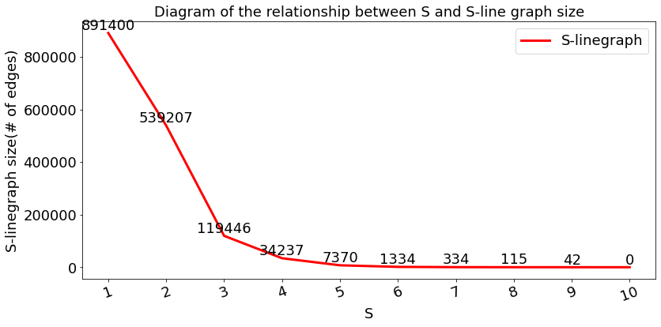

```python
x_ticks = [1, 2, 3, 4, 5, 6, 7, 8, 9, 10]
x = np.arange(len(x_ticks))
y = [891400, 539207, 119446, 34237, 7370, 1334, 334, 115, 42, 0]

plt.figure(figsize=(13, 6))
plt.plot(x, y, color='#FF0000', label='S-linegraph', linewidth=3.0)
for a, b in zip(x, y):
    plt.text(a, b, '%d'%b, ha='center', va= 'bottom', fontsize=18)

plt.xticks([r for r in x], x_ticks, fontsize=18, rotation=20)
plt.yticks(fontsize=18)
plt.xlabel(u'S', fontsize=18)
plt.ylabel(u'S-linegraph size(# of edges)', fontsize=18)
plt.title(u'Diagram of the relationship between S and S-line graph size', fontsize=18)
plt.legend(fontsize=18)

plt.show()
```

#### S-line graph size decreases sharply with increasing S.

## S-line graph application(analysis)

```python
s1 = s_line_graph_arr[0] # S(=1)-line graph
s3 = s_line_graph_arr[2] # S(=3)-line graph
s5 = s_line_graph_arr[4] # S(=5)-line graph
s7 = s_line_graph_arr[6] # S(=7)-line graph

def find_top_10_betweenness_centrality_score(s):
    betweenness_centrality_score_arr = s.s_betweenness_centrality(normalized=True)
    print('Top #\t\ttitle\t\tbetweenness centrality score')
    title_arr = []
    score_arr = []
    for i in range(10):
        score = max(betweenness_centrality_score_arr)
        hyperedge = np.argmax(betweenness_centrality_score_arr)
        title = hyperedge_to_title_dic[hyperedge]
        score_arr.append(score)
        title_arr.append(title)
        betweenness_centrality_score_arr[hyperedge] = 0
        print('Top ',i + 1, '\t\t', title, '\t\t', score)
    return [title_arr, score_arr]

def find_top_10_closeness_centrality_score(s):
    closeness_centrality_score_arr = s.s_closeness_centrality(v=None)
    print('Top #\t\ttitle\t\tcloseness centrality score')
    title_arr = []
    score_arr = []
    for i in range(10):
        score = max(closeness_centrality_score_arr)
        hyperedge = np.argmax(closeness_centrality_score_arr)
        title = hyperedge_to_title_dic[hyperedge]
        score_arr.append(score)
        title_arr.append(title)
        closeness_centrality_score_arr[hyperedge] = 0
        print('Top ',i + 1, '\t\t', title, '\t\t', score)
    return [title_arr, score_arr]

def find_top_10_harmonic_closeness_centrality_score(s):
    harmonic_closeness_centrality_score_arr = s.s_harmonic_closeness_centrality(v=None)
    print('Top #\t\ttitle\t\tharmonic closeness centrality score')
    title_arr = []
    score_arr = []
    for i in range(10):
        score = max(harmonic_closeness_centrality_score_arr)
        hyperedge = np.argmax(harmonic_closeness_centrality_score_arr)
        title = hyperedge_to_title_dic[hyperedge]
        score_arr.append(score)
        title_arr.append(title)
        harmonic_closeness_centrality_score_arr[hyperedge] = 0
        print('Top ',i + 1, '\t\t', title, '\t\t', score)
    return [title_arr, score_arr]

print('-- Top 10 movies with the highest betweenness centrality score:')
print('\nFor S(=1)-line graph:')
s1_betweenness_result = find_top_10_betweenness_centrality_score(s1)
print('\nFor S(=3)-line graph:')
s3_betweenness_result = find_top_10_betweenness_centrality_score(s3)
print('\nFor S(=5)-line graph:')
s5_betweenness_result = find_top_10_betweenness_centrality_score(s5)
print('\nFor S(=7)-line graph:')
s7_betweenness_result = find_top_10_betweenness_centrality_score(s7)

print('\n\n-- Top 10 movies with the highest closeness centrality score:')
print('\nFor S(=1)-line graph:')
s1_closeness_result = find_top_10_closeness_centrality_score(s1)
print('\nFor S(=3)-line graph:')
s3_closeness_result = find_top_10_closeness_centrality_score(s3)
print('\nFor S(=5)-line graph:')
s5_closeness_result = find_top_10_closeness_centrality_score(s5)
print('\nFor S(=7)-line graph:')
s7_closeness_result = find_top_10_closeness_centrality_score(s7)

print('\n\n-- Top 10 movies with the highest harmonic closeness centrality score:')
print('\nFor S(=1)-line graph:')
s1_harmonic_closeness_result = find_top_10_harmonic_closeness_centrality_score(s1)
print('\nFor S(=3)-line graph:')
s3_harmonic_closeness_result = find_top_10_harmonic_closeness_centrality_score(s3)
print('\nFor S(=5)-line graph:')
s5_harmonic_closeness_result = find_top_10_harmonic_closeness_centrality_score(s5)
print('\nFor S(=7)-line graph:')
s7_harmonic_closeness_result = find_top_10_harmonic_closeness_centrality_score(s7)
```

```
-- Top 10 movies with the highest betweenness centrality score:

For S(=1)-line graph:
Top #		title		betweenness centrality score
Top  1 		 Stalingrad 		 0.09049837291240692
Top  2 		 Amor de nadie 		 0.08629073947668076
Top  3 		 Johnny Casanova and the Case of Secret Serum 		 0.05841073766350746
Top  4 		 Grandpa 		 0.05666143074631691
Top  5 		 Family of Spies 		 0.04693305492401123
Top  6 		 Savage Attraction 		 0.04259233549237251
Top  7 		 Play School 		 0.031361620873212814
Top  8 		 Joseph McCain/John St. John/Dennis Dutra/Neil Gallagher 		 0.029640955850481987
Top  9 		 By Dawn's Early Light 		 0.02953033335506916
Top  10 		 Lovely Child 		 0.027186540886759758

For S(=3)-line graph:
Top #		title		betweenness centrality score
Top  1 		 For Whom the Bell Klangs: Part 1 		 2.1961024685879238e-05
Top  2 		 From Here to Machinery 		 1.9344686734257266e-05
Top  3 		 The Adventures of Don Coyote and Sancho Panda 		 1.77768524736166e-05
Top  4 		 Tom & Jerry Kids Show 		 1.2550834981084336e-05
Top  5 		 The S.S. Drainpipe 		 1.0455968549649697e-05
Top  6 		 Tiny Toon Adventures 		 9.197999133903068e-06
Top  7 		 The Dream 		 7.320321401493857e-06
Top  8 		 It Came from Beneath the Sea Duck 		 7.292923328350298e-06
Top  9 		 Splinter Vanishes 		 6.59489342069719e-06
Top  10 		 April Gets in Dutch 		 6.59489342069719e-06

For S(=5)-line graph:
Top #		title		betweenness centrality score
Top  1 		 Episode #1.6286 		 5.376502940634964e-06
Top  2 		 Episode #1.6315 		 4.907933089270955e-06
Top  3 		 Episode #1.6387 		 4.04524507757742e-06
Top  4 		 Episode #1.6357 		 3.921283223462524e-06
Top  5 		 Episode #1.6324 		 3.062396672248724e-06
Top  6 		 Episode #1.6188 		 2.8074609872419387e-06
Top  7 		 Episode #1.6355 		 2.673853259693715e-06
Top  8 		 Episode #1.6351 		 2.248723149023135e-06
Top  9 		 Episode #1.6294 		 2.1847017706022598e-06
Top  10 		 Episode #1.6288 		 1.989279326153337e-06
```

[output cut: 108 more lines]

```
Top  9 		 Episode #1.6357 		 72.76665496826172
Top  10 		 Episode #1.6224 		 72.53333282470703

For S(=7)-line graph:
Top #		title		harmonic closeness centrality score
Top  1 		 Yéti et chuchotement 		 15.0
Top  2 		 Pif des bois 		 15.0
Top  3 		 Cancres et chouchoux 		 13.5
Top  4 		 Le blues sur le lagon 		 13.5
Top  5 		 Une partie de campagne 		 13.5
Top  6 		 Gare aux fantômes 		 13.5
Top  7 		 Aïe mon neveu 		 13.5
Top  8 		 Casse à tous les étages 		 13.5
Top  9 		 Ballade pour une valise 		 13.5
Top  10 		 Chaperon rouge et compagnie 		 13.5
```

## Diagrams of Top 10 movies based on different scores(S=1/3/5/7)

```python
def plot_diagram_of_top_10_score(result, output):
    x = result[0]
    y = result[1]
    plt.figure(figsize=(16, 6))
    plt.bar(x, y, width=0.5)
    plt.xticks(fontsize=10, rotation=20)
    plt.yticks(fontsize=18)
    plt.ylabel(output, fontsize=20)
    diagram_title = 'Diagram of Top 10 movies with the highest ' + output
    plt.title(diagram_title, fontsize=20)
    plt.show()
```

### Diagram of Top 10 movies with the highest betweenness centrality score(S=1)

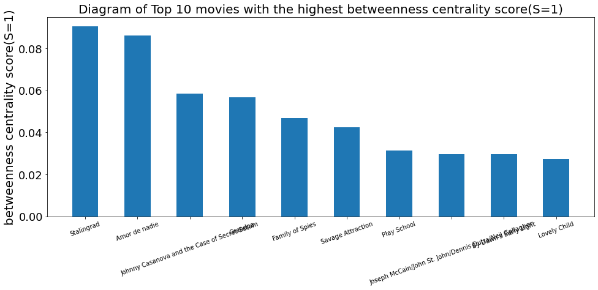

```python
plot_diagram_of_top_10_score(s1_betweenness_result, 'betweenness centrality score(S=1)')
```

### Diagram of Top 10 movies with the highest betweenness centrality score(S=3)

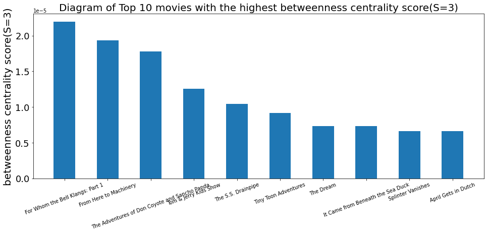

```python
plot_diagram_of_top_10_score(s3_betweenness_result, 'betweenness centrality score(S=3)')
```

### Diagram of Top 10 movies with the highest betweenness centrality score(S=5)

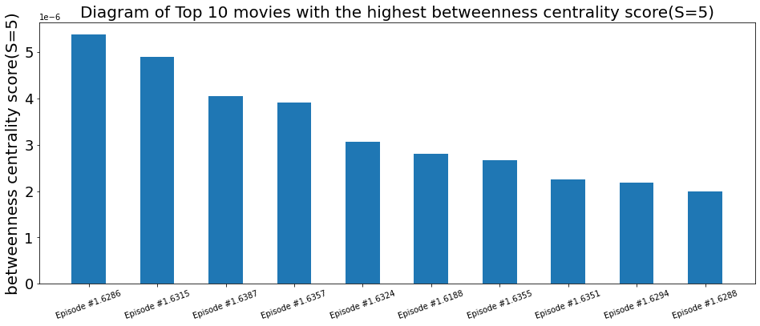

```python
plot_diagram_of_top_10_score(s5_betweenness_result, 'betweenness centrality score(S=5)')
```

### Diagram of Top 10 movies with the highest betweenness centrality score(S=7)

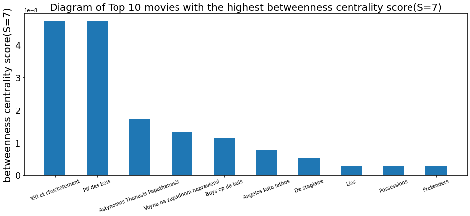

```python
plot_diagram_of_top_10_score(s7_betweenness_result, 'betweenness centrality score(S=7)')
```

### Diagram of Top 10 movies with the highest closeness centrality score(S=1)

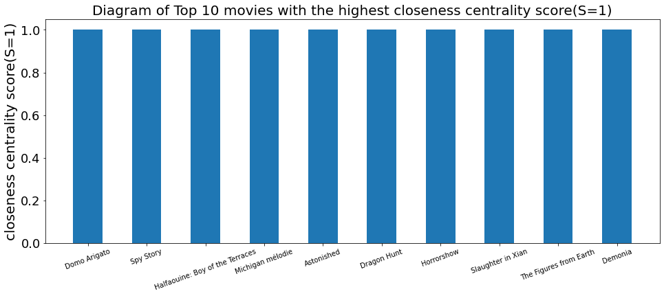

```python
plot_diagram_of_top_10_score(s1_closeness_result, 'closeness centrality score(S=1)')
```

### Diagram of Top 10 movies with the highest closeness centrality score(S=3)

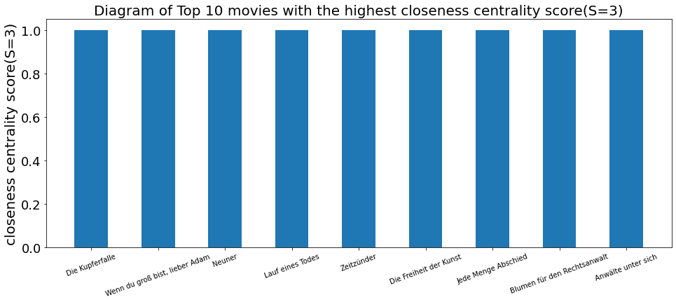

```python
plot_diagram_of_top_10_score(s3_closeness_result, 'closeness centrality score(S=3)')
```

### Diagram of Top 10 movies with the highest closeness centrality score(S=5)

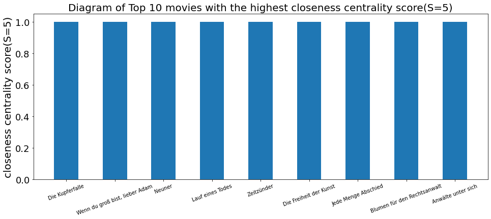

```python
plot_diagram_of_top_10_score(s5_closeness_result, 'closeness centrality score(S=5)')
```

### Diagram of Top 10 movies with the highest closeness centrality score(S=7)

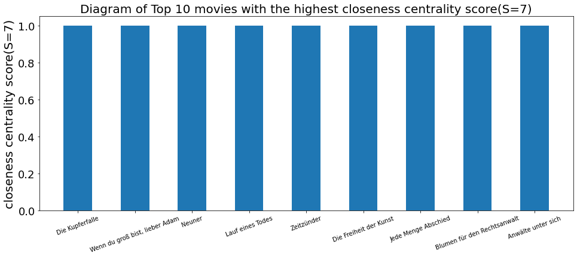

```python
plot_diagram_of_top_10_score(s7_closeness_result, 'closeness centrality score(S=7)')
```

### Diagram of Top 10 movies with the highest harmonic closeness centrality score(S=1)

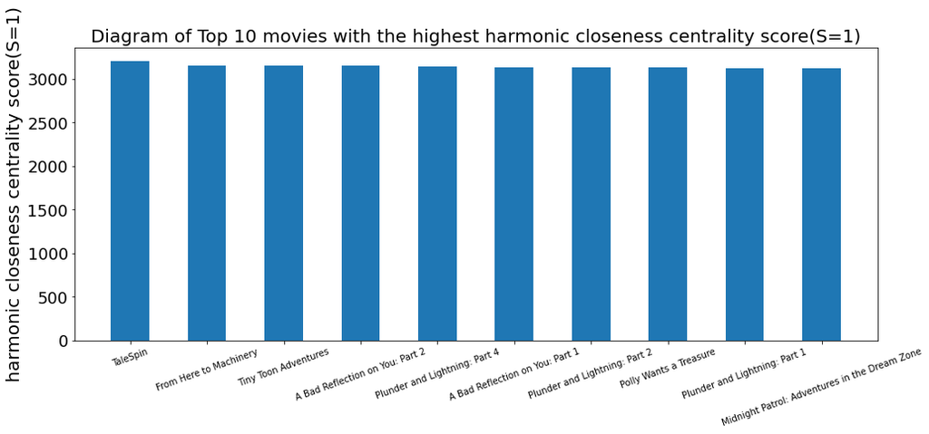

```python
plot_diagram_of_top_10_score(s1_harmonic_closeness_result, 'harmonic closeness centrality score(S=1)')
```

### Diagram of Top 10 movies with the highest harmonic closeness centrality score(S=3)

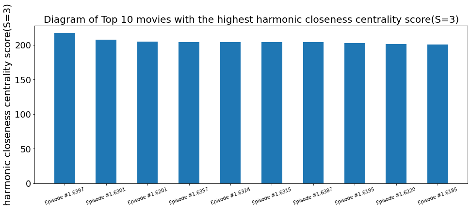

```python
plot_diagram_of_top_10_score(s3_harmonic_closeness_result, 'harmonic closeness centrality score(S=3)')
```

### Diagram of Top 10 movies with the highest harmonic closeness centrality score(S=5)

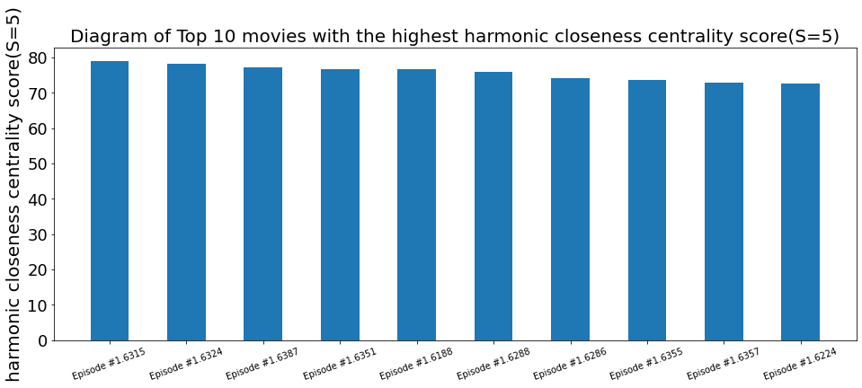

```python
plot_diagram_of_top_10_score(s5_harmonic_closeness_result, 'harmonic closeness centrality score(S=5)')
```

### Diagram of Top 10 movies with the highest harmonic closeness centrality score(S=7)

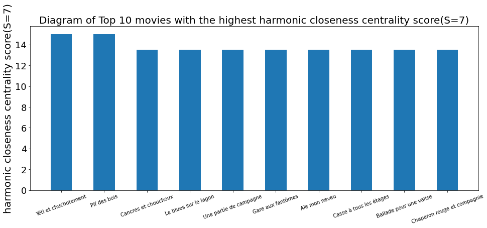

```python
plot_diagram_of_top_10_score(s7_harmonic_closeness_result, 'harmonic closeness centrality score(S=7)')
```